# Usando machine Learning com dataset americano

# Atributos da massa de dados:

## Descrição dos atributos

- Gender Female-0, Male-1
- Ethnicity Hispanic-1, Caucasian-2, African American-3, Asian-4, Native American-5, Others-6
- Mother's Education High School-9, 10, 11, 12, Undergraduate-13, Graduate-14
- Father's Education High School-9, 10, 11, 12, Undergraduate-13, Graduate-14
- Age of Mother at Birth 14-50
- Parent Marriage Status Married-0, Divorced-1
- Special Education for Child Not Needed-0, Need-1
- Delinquency Rated b/w (0-4)
- Math Score %
- Reading Score %
- Parental Involvement (0-4), where 0 is least involved and 4 is most involved
- Self Opinion (0-4), where 0 is low self worth and 4 is Steve Jobs
- Relation w/ Family (0-4), where 0 is hate family and 4 is love family
- Relation w/ Friends (0-4), where 0 is least friendly and 4 is most Friends like FB
- Enjoyment at School (0-4), where 0 is "worst school ever" and 4 is "Best School Ever"
- Self Evaluation of Academics (0-4), where 0 is poor academic image and 4 is best academic image
- Social Life (0-4), where 0 is anti-social and 4 is most social
- Attendance [10-100]%
- Family Income $10K -$100K
- Employement of Mother Unemployed-0, Employed-1
- Employement of Father Unemployed-0, Employed-1
- Housing Status Rental-0, Owned-1
- Neighboorhood (0-4), 0 is worst neighbourhhod, 4 is best neighbourhood
- Free Lunch Yes-0, No-1

## Importando os módulos necessários

```python
# biblioteca de álgebra linear
import numpy as np
# biblioteca de visualização de dados
import pandas as pd
# biblioteca de gráficos
import matplotlib.pyplot as plt
# biblioteca de gráficos
import seaborn as sns
# plota os gráficos na mesma linha
%matplotlib inline
```

## Abre o arquivo

```python
arquivo = pd.read_csv('data.csv')
```

```python
# Exibe as 5 primeiras linhas do arquivo
```

```python
arquivo.head()
```

|  | Ethnicity | Gender | Parent_Invol | Self_Opin | Rel_w_Fam | Rel_w_Fri | Enjoy_Sch | Social_Life | Mother_Edu | Father_Edu | ... | Father_Emp | Housing | Nbhood | Free_Lunch | Deliquency | Math | Read | Eval_Acad_Per | Attendance | drop |
| --- | --- | --- | --- | --- | --- | --- | --- | --- | --- | --- | --- | --- | --- | --- | --- | --- | --- | --- | --- | --- | --- |
| 0 | 4 | 1 | 3 | 4 | 3 | 1 | 3 | 3 | 10 | 6 | ... | 0 | 1 | 1 | 0 | 3 | 34 | 58 | 2 | 56 | 1 |
| 1 | 4 | 0 | 4 | 4 | 3 | 2 | 2 | 2 | 7 | 10 | ... | 1 | 1 | 2 | 0 | 2 | 59 | 56 | 1 | 65 | 1 |
| 2 | 4 | 0 | 2 | 4 | 4 | 3 | 2 | 3 | 12 | 12 | ... | 1 | 0 | 4 | 0 | 0 | 60 | 98 | 4 | 71 | 0 |
| 3 | 2 | 1 | 4 | 2 | 1 | 4 | 1 | 2 | 13 | 10 | ... | 1 | 1 | 2 | 1 | 3 | 31 | 22 | 1 | 55 | 1 |
| 4 | 3 | 0 | 1 | 1 | 3 | 3 | 3 | 4 | 12 | 9 | ... | 1 | 1 | 4 | 0 | 0 | 87 | 11 | 3 | 50 | 0 |

5 rows × 25 columns

```python
# exibe a quantidade de entradas do arquivo (linhas) e atributos
arquivo.info()
```

```
<class 'pandas.core.frame.DataFrame'>
RangeIndex: 400 entries, 0 to 399
Data columns (total 25 columns):
Ethnicity        400 non-null int64
Gender           400 non-null int64
Parent_Invol     400 non-null int64
Self_Opin        400 non-null int64
Rel_w_Fam        400 non-null int64
Rel_w_Fri        400 non-null int64
Enjoy_Sch        400 non-null int64
Social_Life      400 non-null int64
Mother_Edu       400 non-null int64
Father_Edu       400 non-null int64
Age_M_Brth       400 non-null int64
Marr_Divo        400 non-null int64
Sp_Ed            400 non-null int64
Fam_Income       400 non-null int64
Mother_Emp       400 non-null int64
Father_Emp       400 non-null int64
Housing          400 non-null int64
Nbhood           400 non-null int64
Free_Lunch       400 non-null int64
Deliquency       400 non-null int64
Math             400 non-null int64
Read             400 non-null int64
Eval_Acad_Per    400 non-null int64
Attendance       400 non-null int64
drop             400 non-null int64
dtypes: int64(25)
memory usage: 78.2 KB
```

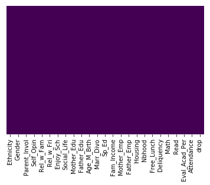

```python
# checando se há dados faltantes no dataset
sns.heatmap(arquivo.isnull(), yticklabels=False, cbar=False, cmap='viridis')
```

## Ou seja, não há dados faltantes em nosso dataset!

### plotando gráficos

```python
sns.set_style('whitegrid')
```

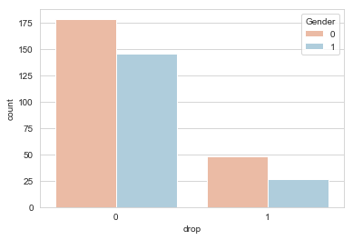

```python
#homens-azul mulheres-vermelho
sns.countplot(x='drop', data=arquivo, hue='Gender', palette="RdBu")
```

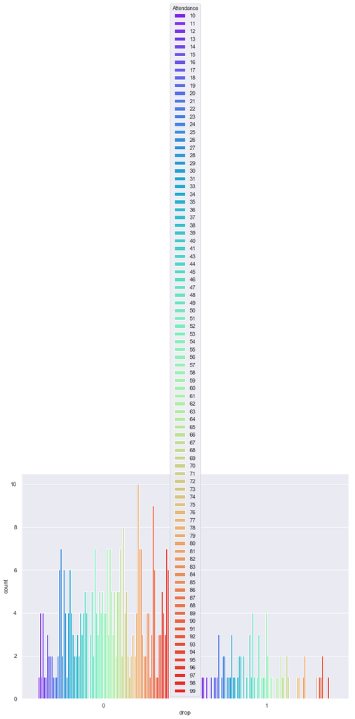

```python
sns.set(style='darkgrid')

sns.set(rc={'figure.figsize':(11.7,8.27)})
sns.countplot(x='drop', data=arquivo, hue='Attendance', palette="rainbow")
```

### como podemos perceber, as frequências influenciam um pouco a evasão

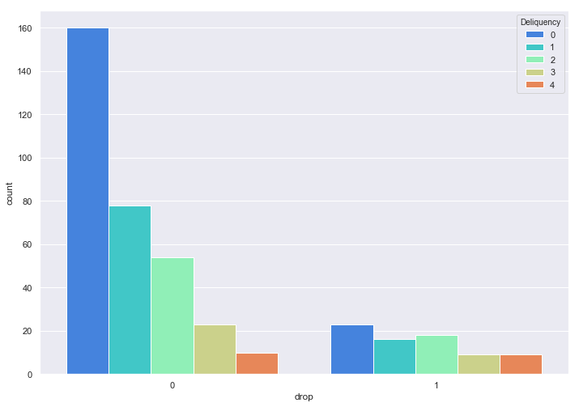

```python
sns.countplot(x='drop', data=arquivo, hue='Deliquency', palette="rainbow")
```

### A maioria dos não delinquentes não evadiram, confirmando um parâmetro bom para calcular a não-evasão

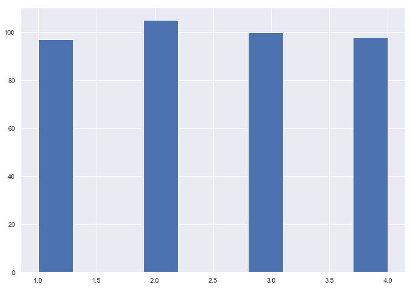

```python
arquivo['Ethnicity'].hist()
```

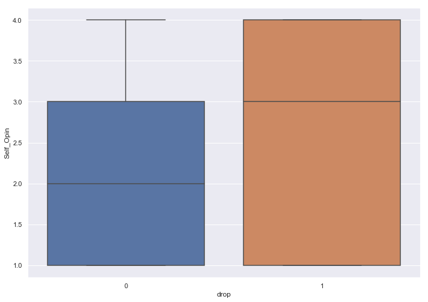

```python
sns.boxplot(x='drop', y='Self_Opin', data=arquivo)
```

### Pessoas que se consideravam melhor no curso evadiram mais

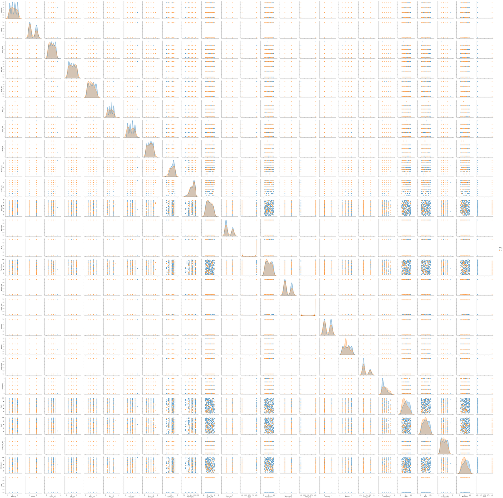

```python
sns.pairplot(arquivo, hue='drop')
```

# Todas as relações com o 'drop', por ser um valor binário, atestam o uso de um modelo de regressão logística

## treinando a máquina

```python
from sklearn.model_selection import train_test_split
```

```python
# tudo menos a coluna 'drop'
```

```python
X = arquivo.drop('drop', axis=1)
```

```python
Y = arquivo['drop']
```

```python
# dividindo os dados em treino e teste
x_train, x_test, y_train, y_test = train_test_split(X, Y, test_size=0.30, random_state=1)
```

# Regressão Logística

```python
#importando a regressão Logística
```

```python
from sklearn.linear_model import LogisticRegression
```

```python
# instanciao objeto da regressao logistica
```

```python
logmodel = LogisticRegression()
```

```python
logmodel.fit(x_train, y_train)
```

```
LogisticRegression(C=1.0, class_weight=None, dual=False, fit_intercept=True,
          intercept_scaling=1, max_iter=100, multi_class='warn',
          n_jobs=None, penalty='l2', random_state=None, solver='warn',
          tol=0.0001, verbose=0, warm_start=False)
```

```python
pred_probs = logmodel.predict_proba(arquivo.drop('drop', axis=1))
```

```python
prob1 = pred_probs[:, 1]
```

```python
prob2 = pred_probs[:, 0]
```

```python
# probabilidade de ser 1
print("probabilidade de evadir")
print('\n')
print(prob1)
print('\n')
print("probabilidade de não-evadir")
print('\n')
print(prob2)
print('\n')
print('Evasões')
print(arquivo['drop'])
```

[output not shown]

[output cut: 86 more lines]

```
386    0
387    0
388    0
389    0
390    0
391    1
392    0
393    0
394    0
395    0
396    0
397    1
398    0
399    0
Name: drop, Length: 400, dtype: int64
```

```python
predictions = logmodel.predict(x_test)
```

```python
from sklearn.metrics import classification_report, accuracy_score
```

```python
accuracy_score(y_test, predictions)
```

```
0.7916666666666666
```

```python
print(classification_report(y_test, predictions))
```

```
              precision    recall  f1-score   support

           0       0.80      0.98      0.88        95
           1       0.50      0.08      0.14        25

   micro avg       0.79      0.79      0.79       120
   macro avg       0.65      0.53      0.51       120
weighted avg       0.74      0.79      0.73       120
```

```python
from sklearn.metrics import confusion_matrix
```

```python
confusion_matrix = confusion_matrix(y_test, predictions)
```

```python
print(confusion_matrix)
```

```
[[93  2]
 [23  2]]
```

## 93 + 2 = 95 previsões corretas

## 2 + 23 = 25 previsões incorretas

# Parte 2 - Utilizando árvores de decisão e florestas aleatórias

```python
# importando a árvore de decisão
from sklearn.tree import DecisionTreeClassifier
```

```python
# instanciando obj
dtree = DecisionTreeClassifier()
```

```python
dtree.fit(x_train, y_train)
```

```
DecisionTreeClassifier(class_weight=None, criterion='gini', max_depth=None,
            max_features=None, max_leaf_nodes=None,
            min_impurity_decrease=0.0, min_impurity_split=None,
            min_samples_leaf=1, min_samples_split=2,
            min_weight_fraction_leaf=0.0, presort=False, random_state=None,
            splitter='best')
```

```python
pred = dtree.predict(x_test)
```

```python
accuracy_score(y_test, pred)
```

```
0.7083333333333334
```

```python
from sklearn.metrics import confusion_matrix
confusion_matrix = confusion_matrix(y_test, pred)
print(confusion_matrix)
```

```
[[80 15]
 [20  5]]
```

```python
print(classification_report(y_test, pred))
```

```
              precision    recall  f1-score   support

           0       0.80      0.84      0.82        95
           1       0.25      0.20      0.22        25

   micro avg       0.71      0.71      0.71       120
   macro avg       0.53      0.52      0.52       120
weighted avg       0.69      0.71      0.70       120
```

## Usando florestas aleatórias

```python
from sklearn.ensemble import RandomForestClassifier
```

```python
rfc = RandomForestClassifier(n_estimators=200) # 100 árvores aleatórias
```

```python
rfc.fit(x_train, y_train)
```

```
RandomForestClassifier(bootstrap=True, class_weight=None, criterion='gini',
            max_depth=None, max_features='auto', max_leaf_nodes=None,
            min_impurity_decrease=0.0, min_impurity_split=None,
            min_samples_leaf=1, min_samples_split=2,
            min_weight_fraction_leaf=0.0, n_estimators=200, n_jobs=None,
            oob_score=False, random_state=None, verbose=0,
            warm_start=False)
```

```python
pred_probs = rfc.predict_proba(arquivo.drop('drop', axis=1))
```

```python
prob1 = pred_probs[:, 1]
```

```python
prob0 = pred_probs[:, 0]
```

```python
# probabilidade de ser 1
print("probabilidade de evadir")
print('\n')
print(prob1)
print('\n')
print("probabilidade de não-evadir")
print('\n')
print(prob0)
print('\n')
print('Evasões')
print(arquivo['drop'])
```

[output not shown]

[output cut: 86 more lines]

```
386    0
387    0
388    0
389    0
390    0
391    1
392    0
393    0
394    0
395    0
396    0
397    1
398    0
399    0
Name: drop, Length: 400, dtype: int64
```

```python
rfc_pred = rfc.predict(x_test)
```

```python
print(classification_report(y_test, rfc_pred))
```

```
              precision    recall  f1-score   support

           0       0.80      1.00      0.89        95
           1       1.00      0.04      0.08        25

   micro avg       0.80      0.80      0.80       120
   macro avg       0.90      0.52      0.48       120
weighted avg       0.84      0.80      0.72       120
```

```python
accuracy_score(y_test, rfc_pred)
```

```
0.8
```

## Conclusão: Ainda é muito difícil para a máquina, com base nos n parâmetros informados, predizer com precisão > 80 % se um aluno é capaz ou não de evadir a escola

## Deve-se angariar ainda mais informações à respeito do aluno, para que se possa estabelecer melhores relações com a evasão